# Chapter9 Summary

## Setup

```r
setwd("/Users/anjali/Documents/university/Econ_5305/code_directory/Chapter9/")
rm(list = ls())
```

```r
library(openxlsx)
library(readxl)
library(ggplot2)
library(dynlm)
library(forecast)
library(urca)
library(lubridate)
library(TSstudio)
```

```r
# create a vector to store reference to all the models
model_names <- c()
model_aic <- c()
model_bic <- c()
model_cor <- c()
model_stationary <- c()
model_invertible <-c()
model_res_box_text <- c()
```

```r
store.function <- function(name = "None",this_model,DATA,stationary = TRUE,invertible = TRUE){
  model_names <<- append(model_names,name)
  model_aic <<- append(model_aic,AIC(this_model))
  model_bic <<- append(model_bic,BIC(this_model))
  this_cor <<- cor(fitted(this_model), DATA, use="pairwise.complete.obs")^2
  model_cor<<-append(model_cor,this_cor)
  this_res_box <<- Box.test(this_model$residuals, type="Ljung-Box")
  model_res_box_text<<-append(model_res_box_text,this_res_box$p.value)
  model_stationary <<- append(model_stationary,stationary)
  model_invertible <<- append(model_invertible,invertible)
}
```

# From Chapter 8

```r
data_q2 <- read_excel("q2_q3_housing.xlsx", sheet ="SanDiego")
raw_san_diego <- ts(data_q2[ , c( "Index_NSA" )], start = c(1975, 1), frequency = 12)

# We are aggregating the index so that it is in quarterly form which is comparable to data model sample from the text book.
san_diego <- aggregate(raw_san_diego, nfrequency=4, FUN=mean)
```

```r
cat("House Price Index - San Diego")
```

```
House Price Index - San Diego
```

```r
summary(san_diego)
```

```
   Index_NSA
 Min.   : 16.72
 1st Qu.: 48.51
 Median : 77.48
 Mean   :116.71
 3rd Qu.:180.34
 Max.   :352.76
```

```r
cat("Standard deviation: ", sd(san_diego))
```

```
Standard deviation:  80.74044
```

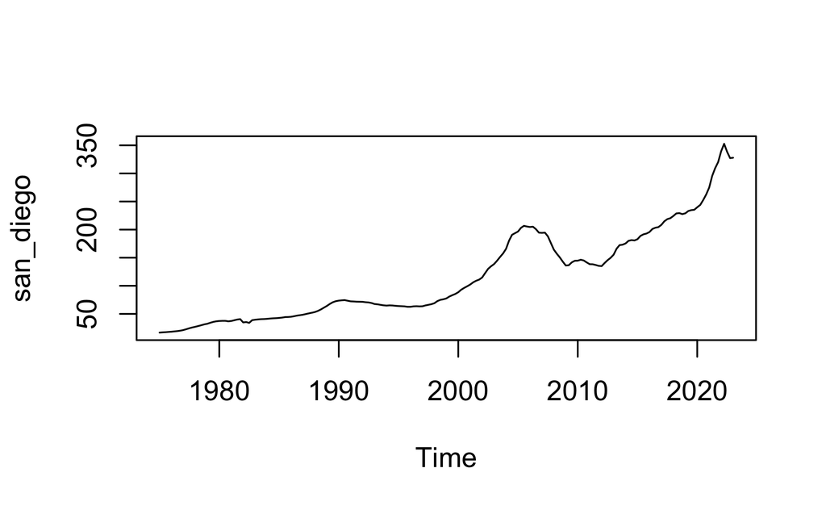

```r
ts.plot(san_diego)
```

```r
ur.df(san_diego,type="drift",lags=0)
```

```
###############################################################
# Augmented Dickey-Fuller Test Unit Root / Cointegration Test #
###############################################################

The value of the test statistic is: 3.2982 19.1342
```

**Notes:** The series has a unit root and there is a stochastic trend. It appears to be a random walk with drift. We will look at the first difference / difference(log) of the series. In the textbook section 8.3 modeling for the the house price index has been done on the Growth Function (diff(log)).

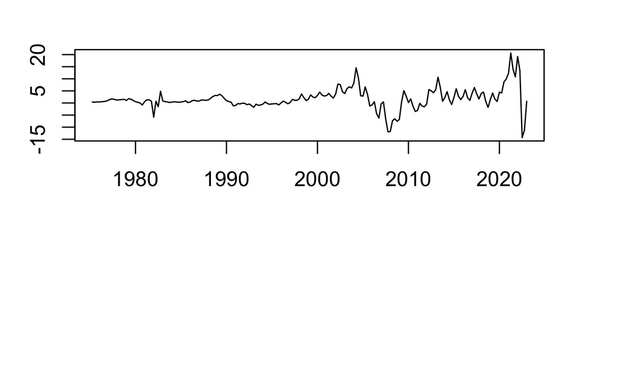

```r
d_san_diego <- diff(san_diego)
dlog_san_diego <- diff(log(san_diego))
par(mfrow=c(2,1) , mar = c(2, 3, 2, 3))
ts.plot(d_san_diego)
ts.plot(dlog_san_diego)
```

```r
ur.df(d_san_diego,type="drift",lags=0)
```

```
###############################################################
# Augmented Dickey-Fuller Test Unit Root / Cointegration Test #
###############################################################

The value of the test statistic is: -5.6363 15.8839
```

```r
ur.df(dlog_san_diego,type="drift",lags=0)
```

```
###############################################################
# Augmented Dickey-Fuller Test Unit Root / Cointegration Test #
###############################################################

The value of the test statistic is: -7.4427 27.699
```

** Notes:** Both the 1st difference and Growth Series do not have a unit root. We will do ACF and PACF analysis on the first difference + Growth series to see if the AR(4) model previously identified is still preferred. In general, we prefer the different of log rather than the difference only because it has good Interpretation, growth rate, and it helps to make the variance stationary.

```r
par(mfrow=c(2,2) , mar = c(3, 2, 3, 2))
acf(d_san_diego, main = "ACF - San Diego (1st Diff)")
pacf(d_san_diego, main = "PACF - San Diego (1st Diff)")
```

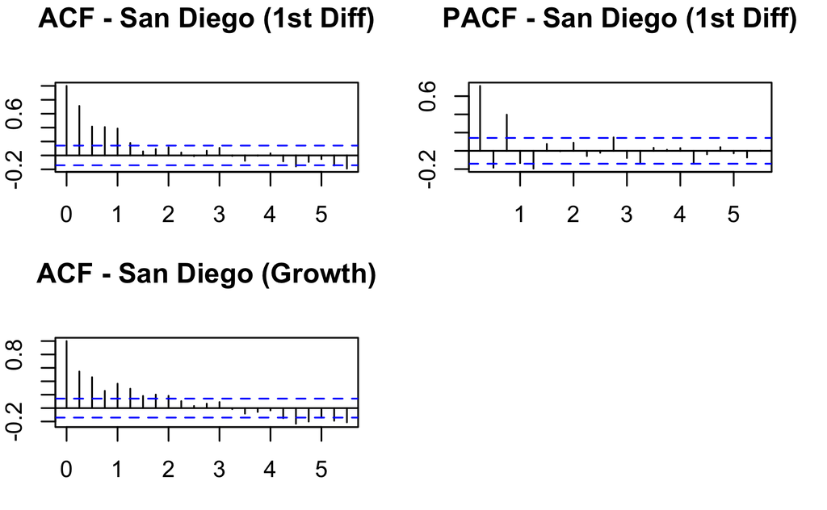

```r
acf(dlog_san_diego, main = "ACF - San Diego (Growth)")
pacf(dlog_san_diego, main = "PACF - San Diego (Growth)")
```

**Notes:** Looking at the PACF we see that there are many more prominent spikes upto 7 as compared to the model in the textbook where there are spikes only till lag = 4. The ACF and PACF here indicate AR(4) and AR(7) models for the growth series. AR(1) is marginally indicated. For chapter 9 we are required to generate the forecasting results for : AR(4), AR(5), and ARMA(2,4)

# In Sample Models before answering the questions

```r
sandiego_AR4 <- arima(dlog_san_diego, order=c(4,0,0))
sandiego_AR4
```

```
Call:
arima(x = dlog_san_diego, order = c(4, 0, 0))

Coefficients:
         ar1     ar2      ar3     ar4  intercept
      0.4637  0.1932  -0.2095  0.2715     0.0153
s.e.  0.0694  0.0756   0.0763  0.0707     0.0059

sigma^2 estimated as 0.0005525:  log likelihood = 447.28,  aic = -882.56
```

```r
cat("\nModel R^2 =  ")
```

```
Model R^2 =
```

```r
cat(cor(fitted(sandiego_AR4),dlog_san_diego , use="pairwise.complete.obs")^2)
```

```
0.390617
```

```r
cat("\nBox Test on the Residuals:  ")
```

```
Box Test on the Residuals:
```

```r
Box.test(sandiego_AR4$residuals, type="Ljung-Box")
```

```
    Box-Ljung test

data:  sandiego_AR4$residuals
X-squared = 0.0093753, df = 1, p-value = 0.9229
```

```r
par(mfrow=c(2,2) , mar = c(3, 2, 3, 2))
plot(sandiego_AR4)
res_AR4 <- residuals(sandiego_AR4)
acf(res_AR4)
```

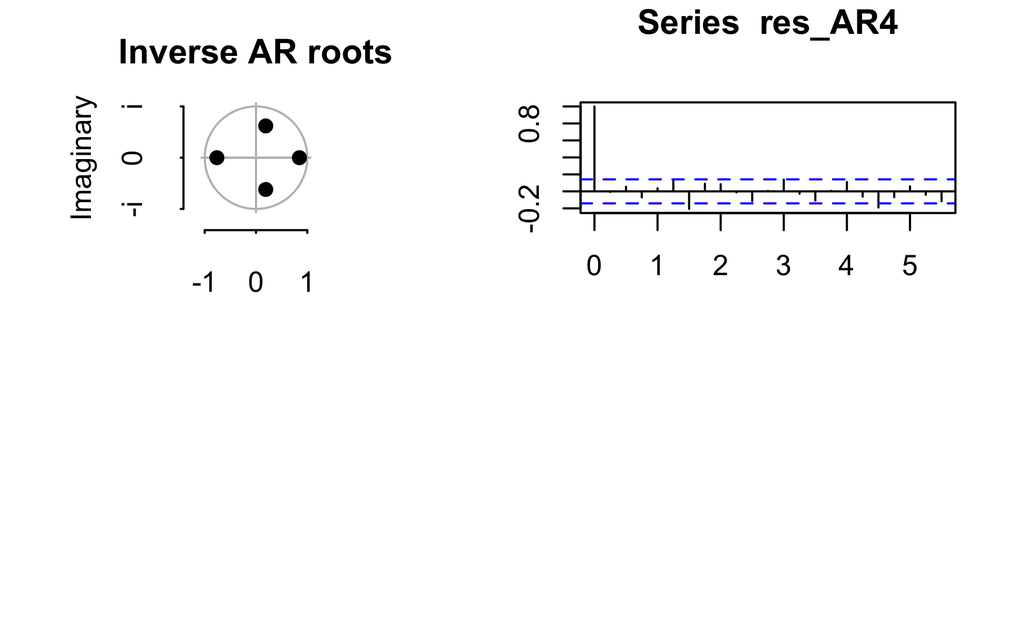

```r
pacf(res_AR4)
```

```r
store.function("San Diego AR(4)",sandiego_AR4,dlog_san_diego,TRUE,TRUE)
```

```r
sandiego_AR5 <- arima(dlog_san_diego, order=c(5,0,0))
sandiego_AR5
```

```
Call:
arima(x = dlog_san_diego, order = c(5, 0, 0))

Coefficients:
         ar1     ar2      ar3     ar4     ar5  intercept
      0.4547  0.2004  -0.2179  0.2559  0.0349     0.0153
s.e.  0.0719  0.0771   0.0783  0.0780  0.0739     0.0061

sigma^2 estimated as 0.0005518:  log likelihood = 447.39,  aic = -880.78
```

```r
cat("\nModel R^2 =  ")
```

```
Model R^2 =
```

```r
cat(cor(fitted(sandiego_AR5),dlog_san_diego , use="pairwise.complete.obs")^2)
```

```
0.3913503
```

```r
cat("\nBox Test on the Residuals:  ")
```

```
Box Test on the Residuals:
```

```r
Box.test(sandiego_AR5$residuals, type="Ljung-Box")
```

```
    Box-Ljung test

data:  sandiego_AR5$residuals
X-squared = 0.013371, df = 1, p-value = 0.9079
```

```r
par(mfrow=c(2,2) , mar = c(3, 2, 3, 2))
plot(sandiego_AR5)
res_AR5 <- residuals(sandiego_AR5)
acf(res_AR5)
```

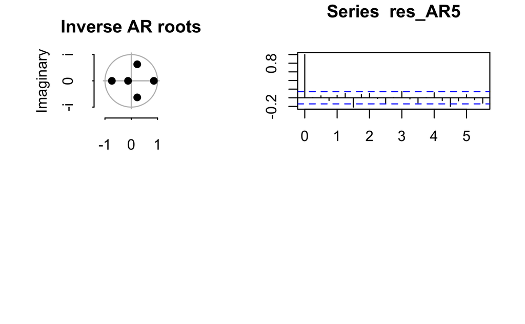

```r
pacf(res_AR5)
```

```r
store.function("San Diego AR(5)",sandiego_AR5,dlog_san_diego,TRUE,TRUE)
```

```r
sandiego_AR_2_MA_4 <- arima(dlog_san_diego, order=c(2,0,4))
sandiego_AR_2_MA_4
cat("\nModel R^2 =  ")
cat(cor(fitted(sandiego_AR_2_MA_4),dlog_san_diego , use="pairwise.complete.obs")^2)
cat("\nBox Test on the Residuals:  ")
Box.test(sandiego_AR_2_MA_4$residuals, type="Ljung-Box")

par(mfrow=c(2,2) , mar = c(3, 2, 3, 2))
plot(sandiego_AR_2_MA_4)
res_ARMA <- residuals(sandiego_AR_2_MA_4)
acf(res_ARMA)
pacf(res_ARMA)
store.function("San Diego ARMA(2,4)",sandiego_AR_2_MA_4,dlog_san_diego,TRUE,TRUE)
```

[output not shown]

```r
# combine everything into 1 large data frame
all_models <- data.frame(model_names, model_aic, model_bic, model_cor, model_res_box_text,model_stationary, model_invertible)
all_models
```

| model_names | model_aic | model_bic | model_cor | model_res_box_text | model_stationary | model_invertible |
| --- | --- | --- | --- | --- | --- | --- |
| San Diego AR(4) | -882.5558 | -863.0108 | 0.3906170 | 0.9228646 | TRUE | TRUE |
| San Diego AR(5) | -880.7795 | -857.9770 | 0.3913503 | 0.9079450 | TRUE | TRUE |
| San Diego ARMA(2,4) | -896.2044 | -870.1445 | 0.4471071 | 0.8362461 | TRUE | TRUE |

#### All models have been setup and in sample evaluations are done.

# Question 3 Forecast Optimality Tests

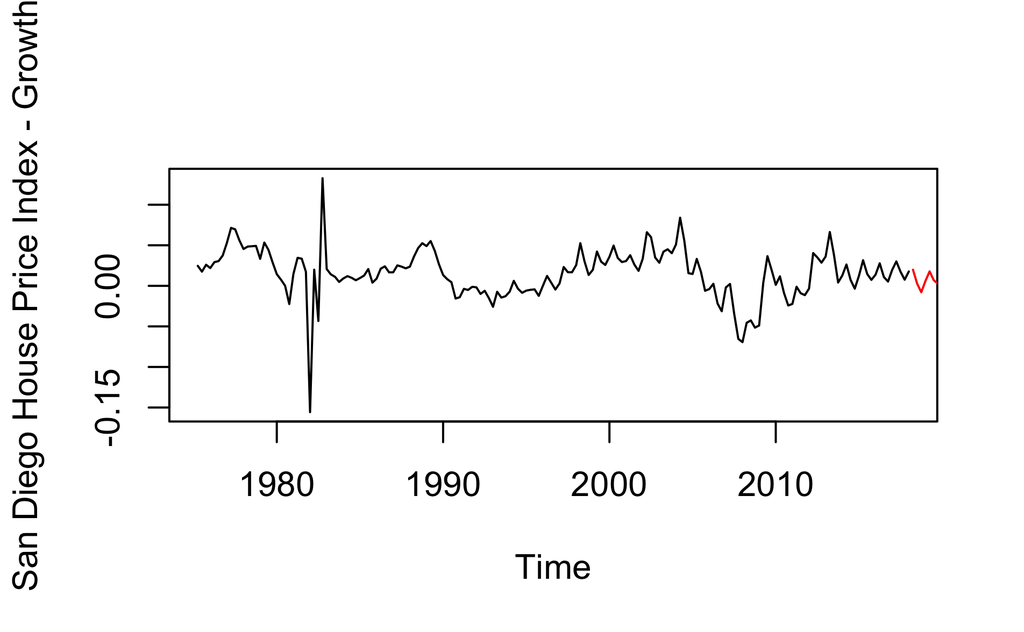

```r
prediction_size <- round(length(dlog_san_diego)*0.10,0) + 1
split <- ts_split(ts.obj = dlog_san_diego, sample.out = prediction_size)
es <- split$train
ps <- split$test
plot(es, ylab="San Diego House Price Index - Growth")
lines(ps,col = "red")
```

```r
estimation_size <- length(es)
length(es)
```

```
[1] 172
```

```r
length(ps)
```

```
[1] 20
```

```r
# Model 1 AR(4)
fcast1<-numeric(prediction_size)
ferror1<-numeric(prediction_size)
loss1<-numeric(prediction_size)

for (i in  1: prediction_size) {
refit_AR4 <- Arima(dlog_san_diego[1:estimation_size + i], model=sandiego_AR4)
fcast1[i]<-forecast(refit_AR4, h=1)$mean
ferror1[i] <- ps[i] - fcast1[i]
loss1[i] <- ferror1[i]^2
}

mpetest1 <- lm(ferror1 ~ 1)
summary(mpetest1)
```

```
Call:
lm(formula = ferror1 ~ 1)

Residuals:
       Min         1Q     Median         3Q        Max
-0.0309820 -0.0044594 -0.0000261  0.0080236  0.0242634

Coefficients:
              Estimate Std. Error t value Pr(>|t|)
(Intercept) -9.297e-05  2.881e-03  -0.032    0.975

Residual standard error: 0.01289 on 19 degrees of freedom
```

```r
IETest1 <- lm(ferror1 ~ fcast1)
summary(IETest1)
```

```
Call:
lm(formula = ferror1 ~ fcast1)

Residuals:
      Min        1Q    Median        3Q       Max
-0.015005 -0.004275  0.001087  0.004321  0.013664

Coefficients:
             Estimate Std. Error t value Pr(>|t|)
(Intercept) -0.011756   0.002663  -4.415 0.000334 ***
fcast1       0.610958   0.105272   5.804 1.69e-05 ***
---
Signif. codes:  0 ‘***’ 0.001 ‘**’ 0.01 ‘*’ 0.05 ‘.’ 0.1 ‘ ’ 1

Residual standard error: 0.007813 on 18 degrees of freedom
Multiple R-squared:  0.6517,    Adjusted R-squared:  0.6324
F-statistic: 33.68 on 1 and 18 DF,  p-value: 1.689e-05
```

```r
# Model 2 AR(5)
fcast2<-numeric(prediction_size)
ferror2<-numeric(prediction_size)
loss2<-numeric(prediction_size)

for (i in  1: prediction_size) {
refit_AR5 <- Arima(dlog_san_diego[1:estimation_size + i], model=sandiego_AR5)
fcast2[i]<-forecast(refit_AR5, h=1)$mean
ferror2[i] <- ps[i] - fcast2[i]
loss2[i] <- ferror2[i]^2
}
mpetest2 <- lm(ferror2 ~ 1)
summary(mpetest2)
```

```
Call:
lm(formula = ferror2 ~ 1)

Residuals:
      Min        1Q    Median        3Q       Max
-0.031963 -0.004456 -0.000402  0.008359  0.025115

Coefficients:
              Estimate Std. Error t value Pr(>|t|)
(Intercept) -0.0002098  0.0029597  -0.071    0.944

Residual standard error: 0.01324 on 19 degrees of freedom
```

```r
IETest2 <- lm(ferror2 ~ fcast2)
summary(IETest2)
```

```
Call:
lm(formula = ferror2 ~ fcast2)

Residuals:
      Min        1Q    Median        3Q       Max
-0.017044 -0.003852  0.001496  0.004738  0.014325

Coefficients:
             Estimate Std. Error t value Pr(>|t|)
(Intercept) -0.011837   0.002946  -4.018 0.000807 ***
fcast2       0.605369   0.116298   5.205 5.97e-05 ***
---
Signif. codes:  0 ‘***’ 0.001 ‘**’ 0.01 ‘*’ 0.05 ‘.’ 0.1 ‘ ’ 1

Residual standard error: 0.008592 on 18 degrees of freedom
Multiple R-squared:  0.6008,    Adjusted R-squared:  0.5787
F-statistic:  27.1 on 1 and 18 DF,  p-value: 5.966e-05
```

```r
# Model 3 ARMA(2,4)
fcast3<-numeric(prediction_size)
ferror3<-numeric(prediction_size)
loss3<-numeric(prediction_size)

for (i in  1: prediction_size) {
refit_ARMA24 <- Arima(dlog_san_diego[1:estimation_size + i], model=sandiego_AR_2_MA_4)
fcast3[i]<-forecast(refit_ARMA24, h=1)$mean
ferror3[i] <- ps[i] - fcast3[i]
loss3[i] <- ferror3[i]^2
}
mpetest3 <- lm(ferror3 ~ 1)
summary(mpetest3)
```

```
Call:
lm(formula = ferror3 ~ 1)

Residuals:
      Min        1Q    Median        3Q       Max
-0.040870 -0.007181  0.000168  0.004696  0.028637

Coefficients:
              Estimate Std. Error t value Pr(>|t|)
(Intercept) -0.0006293  0.0032481  -0.194    0.848

Residual standard error: 0.01453 on 19 degrees of freedom
```

```r
IETest3 <- lm(ferror3 ~ fcast3)
summary(IETest3)
```

```
Call:
lm(formula = ferror3 ~ fcast3)

Residuals:
      Min        1Q    Median        3Q       Max
-0.042749 -0.005994  0.000596  0.004867  0.026697

Coefficients:
             Estimate Std. Error t value Pr(>|t|)
(Intercept) -0.002164   0.004422  -0.489    0.630
fcast3       0.078204   0.149270   0.524    0.607

Residual standard error: 0.01481 on 18 degrees of freedom
Multiple R-squared:  0.01502,   Adjusted R-squared:  -0.0397
F-statistic: 0.2745 on 1 and 18 DF,  p-value: 0.6067
```

```r
#Naive Model
fcast_naive<-numeric(prediction_size)
ferror_naive<-numeric(prediction_size)
loss_naive<-numeric(prediction_size)
start_index = length(dlog_san_diego) - prediction_size

for (i in 1:prediction_size){
  fcast_naive[i]<-dlog_san_diego[start_index -1 + i]
  ferror_naive[i]<-dlog_san_diego[start_index+i]- fcast_naive[i]
  loss_naive[i] <-ferror_naive[i]^2
 }

mpetest_naive <- lm(ferror_naive ~ 1)
summary(mpetest_naive)
```

```
Call:
lm(formula = ferror_naive ~ 1)

Residuals:
      Min        1Q    Median        3Q       Max
-0.079275 -0.010338  0.003435  0.015271  0.036698

Coefficients:
              Estimate Std. Error t value Pr(>|t|)
(Intercept) -0.0007788  0.0055726   -0.14     0.89

Residual standard error: 0.02492 on 19 degrees of freedom
```

```r
IETest_naive <- lm(ferror_naive ~ fcast_naive)
summary(IETest_naive)
```

```
Call:
lm(formula = ferror_naive ~ fcast_naive)

Residuals:
      Min        1Q    Median        3Q       Max
-0.072087 -0.009050  0.000613  0.011760  0.037317

Coefficients:
             Estimate Std. Error t value Pr(>|t|)
(Intercept)  0.006756   0.006365   1.061   0.3026
fcast_naive -0.381002   0.188018  -2.026   0.0578 .
---
Signif. codes:  0 ‘***’ 0.001 ‘**’ 0.01 ‘*’ 0.05 ‘.’ 0.1 ‘ ’ 1

Residual standard error: 0.0231 on 18 degrees of freedom
Multiple R-squared:  0.1858,    Adjusted R-squared:  0.1405
F-statistic: 4.106 on 1 and 18 DF,  p-value: 0.0578
```

```r
#Average Model - taking average of last 6 observations
fcast_avg<-numeric(prediction_size)
ferror_avg<-numeric(prediction_size)
loss_avg<-numeric(prediction_size)
start_index = length(dlog_san_diego) - prediction_size

for (i in 1:prediction_size){
  fcast_avg[i]<-(dlog_san_diego[start_index -1 + i] + dlog_san_diego[start_index -2 + i]  + dlog_san_diego[start_index -3 + i] + dlog_san_diego[start_index -4 + i] + dlog_san_diego[start_index -5 + i] + dlog_san_diego[start_index -6 + i])/6

  ferror_avg[i]<-dlog_san_diego[start_index+i]- fcast_avg[i]
  loss_avg[i] <-ferror_avg[i]^2
 }

mpetest_avg <- lm(ferror_avg ~ 1)
summary(mpetest_avg)
```

```
Call:
lm(formula = ferror_avg ~ 1)

Residuals:
      Min        1Q    Median        3Q       Max
-0.087265 -0.008244  0.003896  0.016618  0.049454

Coefficients:
             Estimate Std. Error t value Pr(>|t|)
(Intercept) -0.003364   0.006963  -0.483    0.634

Residual standard error: 0.03114 on 19 degrees of freedom
```

```r
IETest_avg <- lm(ferror_avg ~ fcast_avg)
summary(IETest_avg)
```

```
Call:
lm(formula = ferror_avg ~ fcast_avg)

Residuals:
     Min       1Q   Median       3Q      Max
-0.06453 -0.01454  0.00144  0.01850  0.05283

Coefficients:
            Estimate Std. Error t value Pr(>|t|)
(Intercept)  0.01556    0.01182   1.317   0.2045
fcast_avg   -0.84643    0.44098  -1.919   0.0709 .
---
Signif. codes:  0 ‘***’ 0.001 ‘**’ 0.01 ‘*’ 0.05 ‘.’ 0.1 ‘ ’ 1

Residual standard error: 0.02915 on 18 degrees of freedom
Multiple R-squared:  0.1699,    Adjusted R-squared:  0.1238
F-statistic: 3.684 on 1 and 18 DF,  p-value: 0.07093
```